# Practical_Lab6

**CSCN8010 - LAB**

**Practical Lab 6 - Logistic Regression**

**Goal :** **Classify the species of an Iris flower given the dimensions of parts of the flower.**

[Iris Dataset](https://scikit-learn.org/stable/auto_examples/datasets/plot_iris_dataset.html)

```python
from sklearn.datasets import load_iris
import numpy as np
import pandas as pd
import seaborn as sns
import matplotlib.pyplot as plt
from sklearn.model_selection import train_test_split
from sklearn.linear_model import LogisticRegression
from sklearn.metrics import accuracy_score
import plotly.graph_objs as go
```

**Analytical Steps**

**Redefining 2 classes for the target variable: virginica and non-virginica**

```python
iris = load_iris()
X = iris.data
y = iris.target
# target variable into two classes: 'virginica' and 'non-virginica'
y_binary = np.where(y == 2, 'virginica', 'non-virginica')
# Checking unique values in the redefined target variable
unique_classes = np.unique(y_binary)
print("Unique classes after redefining:", unique_classes)
```

```
Unique classes after redefining: ['non-virginica' 'virginica']
```

**Explore the data**

```python
# dataframe with features and target variable
df = pd.DataFrame(data=iris.data, columns=iris.feature_names)
df['target'] = y_binary
# Group the dataframe
grouped = df.groupby('target')
# descriptive statistics for each class
statistics = grouped.describe()
print("Descriptive Statistics for each class:")
statistics.head()
```

```
Descriptive Statistics for each class:
```

| target | sepal length (cm) count | sepal length (cm) mean | sepal length (cm) std | sepal length (cm) min | sepal length (cm) 25% | sepal length (cm) 50% | sepal length (cm) 75% | sepal length (cm) max | sepal width (cm) count | sepal width (cm) mean | ... | petal length (cm) 75% | petal length (cm) max | petal width (cm) count | petal width (cm) mean | petal width (cm) std | petal width (cm) min | petal width (cm) 25% | petal width (cm) 50% | petal width (cm) 75% | petal width (cm) max |
| --- | --- | --- | --- | --- | --- | --- | --- | --- | --- | --- | --- | --- | --- | --- | --- | --- | --- | --- | --- | --- | --- |
| non-virginica | 100.0 | 5.471 | 0.641698 | 4.3 | 5.000 | 5.4 | 5.9 | 7.0 | 100.0 | 3.099 | ... | 4.325 | 5.1 | 100.0 | 0.786 | 0.565153 | 0.1 | 0.2 | 0.8 | 1.3 | 1.8 |
| virginica | 50.0 | 6.588 | 0.635880 | 4.9 | 6.225 | 6.5 | 6.9 | 7.9 | 50.0 | 2.974 | ... | 5.875 | 6.9 | 50.0 | 2.026 | 0.274650 | 1.4 | 1.8 | 2.0 | 2.3 | 2.5 |

2 rows × 32 columns

**Histogram**

```
No artists with labels found to put in legend.  Note that artists whose label start with an underscore are ignored when legend() is called with no argument.
```

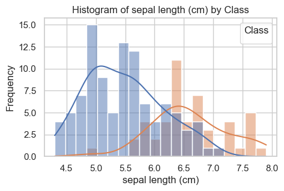

```
No artists with labels found to put in legend.  Note that artists whose label start with an underscore are ignored when legend() is called with no argument.
```

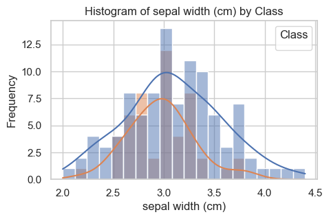

```
No artists with labels found to put in legend.  Note that artists whose label start with an underscore are ignored when legend() is called with no argument.
```

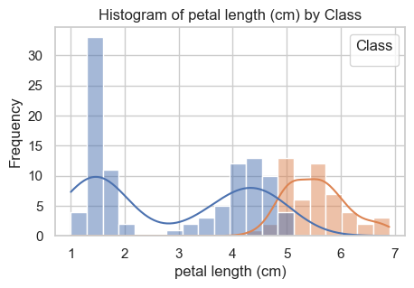

```
No artists with labels found to put in legend.  Note that artists whose label start with an underscore are ignored when legend() is called with no argument.
```

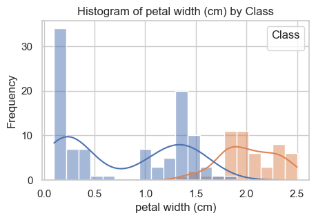

```python
# Set style for the plots
sns.set(style="whitegrid")
# histograms for each feature, distinguishing between classes with the hue argument
for feature in iris.feature_names:
    plt.figure(figsize=(5, 3))
    sns.histplot(data=df, x=feature, hue='target', kde=True, bins=20)
    plt.title(f'Histogram of {feature} by Class')
    plt.xlabel(feature)
    plt.ylabel('Frequency')
    plt.legend(title='Class')
    plt.show()
```

**Correlation Matrix**

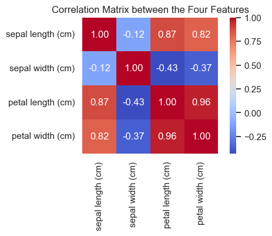

```python
# correlation matrix
correlation_matrix = df[iris.feature_names].corr()
# Plot the correlation matrix
plt.figure(figsize=(5, 3))
sns.heatmap(correlation_matrix, annot=True, cmap='coolwarm', fmt=".2f", square=True)
plt.title('Correlation Matrix between the Four Features')
plt.show()
```

**3 additional graphs**

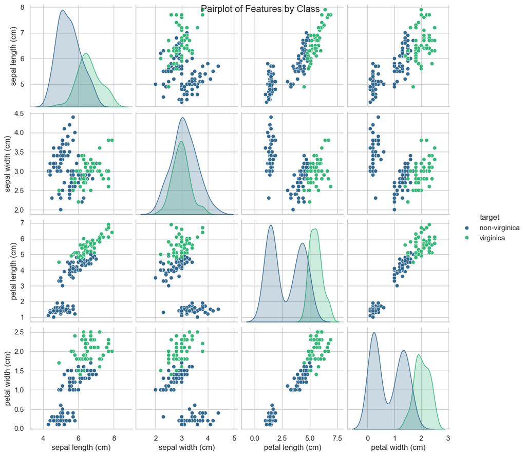

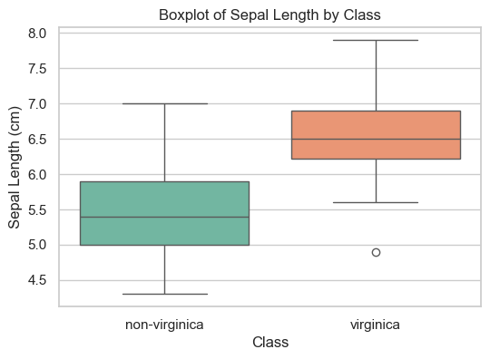

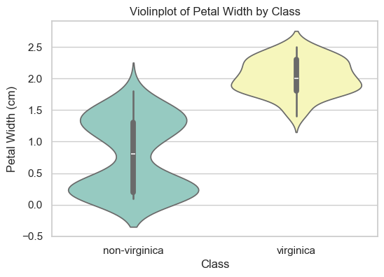

```python
# Pairplot
plt.figure(figsize=(6, 4))
sns.pairplot(df, hue='target', palette='viridis')
plt.suptitle('Pairplot of Features by Class')
plt.show()
# Boxplot
plt.figure(figsize=(6, 4))
sns.boxplot(data=df, x='target', y='sepal length (cm)', palette='Set2')
plt.title('Boxplot of Sepal Length by Class')
plt.xlabel('Class')
plt.ylabel('Sepal Length (cm)')
plt.show()
# Violinplot
plt.figure(figsize=(6, 4))
sns.violinplot(data=df, x='target', y='petal width (cm)', palette='Set3')
plt.title('Violinplot of Petal Width by Class')
plt.xlabel('Class')
plt.ylabel('Petal Width (cm)')
plt.show()
```

**Explaination**

**1. Pairplot:**

**This picture shows how four things (sepal length, sepal width, petal length, and petal width) are related to each other. It's like drawing lines between them. It helps us understand how these things are connected.**

**The diagonal line in the graph tells us how much the values are different from each other. It's called kernel density estimates.**

**The off-diagonal plots show colored dots for each feature, either in virginica or non-virginica.**

**Looking at the pairplot helps us see which features separate different groups. If we see groups of features together, that means they are good at separating the different groups.**

**2. Boxplot:**

**The boxplot shows how a group of things are spread out based on how they belong to different classes.**

**The box represents the interquartile range (IQR), with the line inside representing the median.**

**When we make a box and whisker plot, we draw lines that go from the box to the smallest and biggest numbers within a certain range. Any numbers that are outside of this range are called outliers.**

**The boxplot helps us understand the data by showing us how the numbers are spread out. It can also help us find numbers that don't belong and compare the numbers between different groups.**

**3. Violinplot :**

**The violin plot combines a boxplot with a kernel density plot.**

**Similar to the boxplot, the width of the violin represents the distribution of values for each class.**

**The white dot represents the median, and the thick black line represents the interquartile range.**

**The width of the violin at any given point represents the density of data points at that value.**

**A violinplot is a type of graph that helps us understand numbers in a way that is easier to see. It helps us see how things are different or similar.**

**Split the data**

```python
# training set (120 records) and a temporary set (30 records)
X_train_temp, X_test, y_train_temp, y_test = train_test_split(X, y_binary, test_size=30, random_state=42)
# validation set (15 records) and a test set (15 records)
X_train, X_val, y_train, y_val = train_test_split(X_train_temp, y_train_temp, test_size=15, random_state=42)
# Print the shapes of the resulting sets
print("Training set:", X_train.shape, y_train.shape)
print("Validation set:", X_val.shape, y_val.shape)
print("Test set:", X_test.shape, y_test.shape)
```

```
Training set: (105, 4) (105,)
Validation set: (15, 4) (15,)
Test set: (30, 4) (30,)
```

```python
# Initialize logistic regression models
models = []
# Features sets
feature_sets = [
    ['sepal length (cm)'],
    ['sepal width (cm)'],
    ['petal length (cm)'],
    ['petal width (cm)'],
    ['sepal length (cm)', 'sepal width (cm)'],
    ['sepal length (cm)', 'petal length (cm)'],
    ['sepal length (cm)', 'petal width (cm)'],
    ['sepal width (cm)', 'petal length (cm)'],
    ['sepal width (cm)', 'petal width (cm)'],
    ['petal length (cm)', 'petal width (cm)'],
    ['sepal length (cm)', 'sepal width (cm)', 'petal length (cm)'],
    ['sepal length (cm)', 'sepal width (cm)', 'petal width (cm)'],
    ['sepal length (cm)', 'petal length (cm)', 'petal width (cm)'],
    ['sepal width (cm)', 'petal length (cm)', 'petal width (cm)'],
    ['sepal length (cm)', 'sepal width (cm)', 'petal length (cm)', 'petal width (cm)'],
]
# Train logistic regression models
for features in feature_sets:
    model = LogisticRegression(random_state=42, max_iter=1000)
    model.fit(X_train[:, [iris.feature_names.index(feature) for feature in features]], y_train)
    models.append(model)
# Evaluate models on the validation set
best_accuracy = 0
best_model = None
for i, model in enumerate(models, 1):
    y_pred = model.predict(X_val[:, [iris.feature_names.index(feature) for feature in feature_sets[i - 1]]])
    accuracy = accuracy_score(y_val, y_pred)
    print(f"Accuracy for {i} feature(s): {accuracy:.4f}")
    if accuracy > best_accuracy:
        best_accuracy = accuracy
        best_model = model
print("\nBest Model:", best_model)
```

[output not shown]

**Evaluate the models on the validation set**

```python
# Initializing lists for storing results
tables = []
for i, model in enumerate(models, 1):
    # Prediction of probabilities and classes
    probabilities = model.predict_proba(X_val[:, [iris.feature_names.index(feature) for feature in feature_sets[i - 1]]])
    predictions = model.predict(X_val[:, [iris.feature_names.index(feature) for feature in feature_sets[i - 1]]])

    # dataframe to store results
    results = pd.DataFrame({
        'Instance Number': range(1, len(X_val) + 1),
        'Probability of Predicting Virginica': probabilities[:, 1],
        'Predicted Class': predictions,
        'Ground Truth': y_val
    })
    # Append dataframe
    tables.append(results)
for i, table in enumerate(tables, 1):
    print(f"\nTable for Model {i} with {i} feature(s):")
    print(table)
```

```
Table for Model 1 with 1 feature(s):
    Instance Number  Probability of Predicting Virginica Predicted Class  \
0                 1                             0.345433   non-virginica
1                 2                             0.160971   non-virginica
2                 3                             0.020291   non-virginica
3                 4                             0.053899   non-virginica
4                 5                             0.094650   non-virginica
5                 6                             0.942736       virginica
6                 7                             0.491984   non-virginica
7                 8                             0.260395   non-virginica
8                 9                             0.223344   non-virginica
9                10                             0.491984   non-virginica
10               11                             0.639926       virginica
11               12                             0.345433   non-virginica
12               13                             0.345433   non-virginica
```

[output cut: 509 more lines]

**Summary:** Accuracy: The ratio of correctly predicted instances to the total number of instances. It provides an overall measure of how often the model makes correct predictions.

Precision: The ratio of correctly predicted positive observations to the total predicted positive observations. It measures the model's ability to avoid false positives.

Recall (Sensitivity): The ratio of correctly predicted positive observations to the total actual positive observations. It measures the model's ability to find all positive instances.

F1-score: The harmonic mean of precision and recall. It provides a balance between precision and recall, especially when there is an imbalance between classes.

**Decision boundary for three models**

```python
# function to plot decision boundary
def plot_decision_boundary(model, features, X_val, y_val):
    # Extract features
    X_val_selected = X_val[:, [iris.feature_names.index(feature) for feature in features]]
    # Create meshgrid
    if len(features) == 1:
        x_min, x_max = X_val_selected.min() - 0.5, X_val_selected.max() + 0.5
        xx = np.linspace(x_min, x_max, 1000).reshape(-1, 1)
        yy = model.predict_proba(xx)
        #decision boundary and validation data
        fig = go.Figure()
        fig.add_trace(go.Scatter(x=xx.squeeze(), y=yy[:, 1], mode='lines', name='Decision Boundary', line=dict(color='red')))
        fig.add_trace(go.Scatter(x=X_val_selected.squeeze(), y=y_val, mode='markers', name='Validation Data'))
        fig.update_layout(title=f'Decision Boundary for {features[0]} Feature', xaxis_title=features[0], yaxis_title='Virginica Probability')
        fig.show()
    else:
        x1_min, x1_max = X_val_selected[:, 0].min() - 0.5, X_val_selected[:, 0].max() + 0.5
        x2_min, x2_max = X_val_selected[:, 1].min() - 0.5, X_val_selected[:, 1].max() + 0.5
        x1, x2 = np.meshgrid(np.linspace(x1_min, x1_max, 100), np.linspace(x2_min, x2_max, 100))

        if len(features) == 3:
            x3 = (-model.intercept_ - model.coef_[0][0] * x1 - model.coef_[0][1] * x2) / model.coef_[0][2]
        # Predict classes
        y_pred = model.predict(X_val_selected)
        Z = y_pred.reshape(x1.shape)
        # decision boundary and validation data
        fig = go.Figure()
        if len(features) == 3:
            fig.add_trace(go.Surface(x=x1, y=x2, z=x3, opacity=0.7, showscale=False))
        fig.add_trace(go.Scatter3d(x=X_val_selected[:, 0], y=X_val_selected[:, 1], z=y_val,
                                     mode='markers', marker=dict(size=5, color=y_val, colorscale='Viridis', opacity=0.8)))
        fig.update_layout(scene=dict(xaxis_title=features[0], yaxis_title=features[1], zaxis_title='Virginica Probability'),
                          title=f'Decision Boundary for {len(features)} Features', autosize=False,
                          width=800, height=600, margin=dict(l=0, r=0, b=0, t=40))
        fig.show()
# Plot decision boundaries for models with 1, 2, and 3 features
for i, model in enumerate(models[:3], 1):
    plot_decision_boundary(model, feature_sets[i-1], X_val, y_val)
```

[output not shown]

**Failure Modes**

```python
# Initialize lists to store failure modes for each model
failure_modes = []

# Evaluate each model on the validation set
for i, model in enumerate(models, 1):
    # Predict classes
    predictions = model.predict(X_val[:, [iris.feature_names.index(feature) for feature in feature_sets[i - 1]]])

    # Identify instances where predictions do not match ground truth
    failures = np.where(predictions != y_val)[0]

    # Store failure modes
    failure_modes.append({
        'Model': i,
        'Failed Instances': failures,
        'Predictions': predictions[failures],
        'Ground Truth': y_val[failures]
    })

# Print failure modes for each model
for failure_mode in failure_modes:
    print(f"\nFailure Modes for Model {failure_mode['Model']} with {failure_mode['Model']} feature(s):")
    print("Failed Instances:", failure_mode['Failed Instances'])
    print("Predictions:", failure_mode['Predictions'])
    print("Ground Truth:", failure_mode['Ground Truth'])
```

[output not shown]

[output cut: 19 more lines]

[output not shown]

By analyzing the failed instances for each model, we can identify patterns such as:

1. Instances with overlapping feature values between classes.
2. Instances where the decision boundary is ambiguous.
3. Instances where the model's assumptions or limitations are violated.
4. Instances where the model lacks sufficient training data or generalization ability.

**Best Model**

```python
# validation accuracies for each model
validation_accuracies = []
# Calculate accuracy for each model on the validation set
for i, model in enumerate(models, 1):
    predictions = model.predict(X_val[:, [iris.feature_names.index(feature) for feature in feature_sets[i - 1]]])
    accuracy = accuracy_score(y_val, predictions)
    validation_accuracies.append(accuracy)
# Check validation_accuracies list is not empty
if validation_accuracies:
    # index of the best model based on validation accuracy
    best_model_index = np.argmax(validation_accuracies)
    # Get the best model
    best_model = models[best_model_index]
    # Summarize results of the best model on the test set
    predictions_test = best_model.predict(X_test[:, [iris.feature_names.index(feature) for feature in feature_sets[best_model_index]]])
    accuracy_test = accuracy_score(y_test, predictions_test)
    print("Best Model Summary:")
    print("Validation Accuracy:", validation_accuracies[best_model_index])
    print("Test Accuracy:", accuracy_test)
else:
    print("No validation accuracies calculated. Please check your data or model configurations.")
```

```
Best Model Summary:
Validation Accuracy: 1.0
Test Accuracy: 1.0
```

**The summary of the results on the test set is as follows:**

**Overall, the test accuracy of the selected model will indicate how well it generalizes to new data, providing valuable insights into its performance in real-world scenarios.**